# Supplementary Material - Workplace food environments as intervention leverage points: decision analysis of safe vegetable access for low-income workers in Hanoi

**Authors:** Nguyen Thi Sau, Thi Thu Giang Luu, Nguyen Huu Nhuan, Nguyen Thi Tan Loc, Cory Whitney

This supplementary material provides the full probabilistic decision model, input parameter table, and diagnostic outputs supporting the main article. All code and data are available at https://github.com/sau140288/nifam_favri_companies.

# 1 Decision context and model structure

We apply a probabilistic decision model to assess whether large garment factories in Hanoi, Vietnam should invest in supporting on-site vegetable access for their workers. Two intervention options are evaluated against a *DoNothing* baseline:

- **FarmStand**: The company establishes and manages an on-campus vegetable stand, sourcing directly from contracted farmers. The company bears full establishment and annual operating costs but retains control over supply chain quality, worker access, and pricing.
- **ConnectFarm**: The company facilitates connections between workers and off-site farming cooperatives, enabling direct purchasing without managing a physical stand. Establishment costs are a small fraction of FarmStand costs, but the company has less control over quality and access reliability.
- **DoNothing**: No intervention. Workers rely on existing off-campus food sources. This serves as the counterfactual baseline.

The model evaluates each option in terms of its net financial benefit to the company over a five-year horizon as the Net Present Value (NPV) of the intervention *relative to DoNothing*. A positive NPV indicates that the intervention generates more value (or avoids more cost) than taking no action. All outputs are probability distributions, reflecting full propagation of uncertainty across all input parameters.

# 2 Monte Carlo simulation

We parameterised the model using expert-elicited ranges representing the 5th and 95th percentiles of each uncertain input (see Section 3, Table 1). Monte Carlo simulation with 10,000 model runs was performed using the `decisionSupport` R package (Luedeling et al. 2021), drawing independent samples from each input distribution per run. Costs and benefits are inflated annually using the `inflation_rate` parameter. All future cash flows are discounted to Net Present Value using the `discount_rate`.

Decision outcome variables:

- `decision_farmstand`: NPV of FarmStand minus NPV of DoNothing (million VND, discounted over five years)
- `decision_connectFarm`: NPV of ConnectFarm minus NPV of DoNothing (million VND, discounted over five years)

```r
source("company_model.R")

# Fixed seed ensures reproducibility across full simulation runs
set.seed(84)

source("functions/mcSimulation.R")
company_simulation_results <- mcSimulation(
  estimate = estimate_read_csv("data/company_input.csv"),
  model_function = company_model,
  numberOfModelRuns = 10000,
  functionSyntax = "plainNames"
)
```

# 3 Input parameters

Table 1 lists all model input variables with their expert-elicited uncertainty ranges. **Lower** and **upper** bounds represent the 5th and 95th percentiles of each parameter distribution. Distribution types: *pos-normal* = truncated normal constrained to positive values; *trunc-normal [0,1]* = normal truncated to the unit interval (used for probabilities and fractions); *constant* = fixed value.

Table 1. Model input parameters

Expert-elicited 5th and 95th percentile ranges for all uncertain inputs

| Parameter | 5th %ile | 95th %ile | Distribution | Description |
| --- | --- | --- | --- | --- |
| Economic and model parameters |  |  |  |  |
| Simulation period (years) | 5.00 | 5.00 | constant | Number of years for model simulation |
| Discount rate (%) | 3.00 | 15.00 | pos-normal | Discounting factor |
| Coefficient of variation (%) | 10.00 | 40.00 | pos-normal | Coefficient of variation for annual cash flows (%; vv() expects percent: 10 = 10%) |
| Inflation rate (%) | 3.00 | 7.00 | pos-normal | Inflation rate (%) |
| Prob. farmer revenue sharing | 0.40 | 0.80 | trunc-normal [0,1] | chance of farmers sharing revenue from vegetable sales with company (probability 0-1) |
| One-time establishment costs (million VND) |  |  |  |  |
| Setup: capital (M VND) | 0.27 | 15.00 | pos-normal | cost of establishment capital (million VND) |
| Setup: cleaning (M VND) | 0.08 | 4.00 | pos-normal | cost of cleaning establishment (million VND) |
| Setup: HR staff (M VND) | 0.10 | 5.00 | pos-normal | labor cost of the core team to support establishment (million VND) |
| Setup: participant allowance (M VND) | 0.15 | 8.00 | pos-normal | allowance for extended participants during establishment time (million VND) |
| Setup: promotion (M VND) | 0.18 | 10.00 | pos-normal | cost of establishment promotion (million VND) |
| Setup: stakeholder engagement (M VND) | 0.15 | 8.00 | pos-normal | cost of establishment stakeholder engagement (million VND) |
| Setup: communication (M VND) | 0.11 | 6.00 | pos-normal | cost of establishment communication (million VND) |
| Setup: legal fee (M VND) | 0.06 | 3.00 | pos-normal | cost of establishment legal permission (million VND) |
| Setup: overhead (M VND) | 0.13 | 7.00 | pos-normal | establishment overhead cost. Insitutional costs (million VND) |
| Setup: equipment (M VND) | 0.27 | 15.00 | pos-normal | cost of establishment equipments (million VND) |
| Annual maintaining costs (million VND) |  |  |  |  |
| Annual: monitoring & eval. (M VND) | 0.27 | 15.00 | pos-normal | annual maintaining costs of monitoring and evaluation e.g. project visits, market surveillance (million VND) |
| Annual: depreciation (M VND) | 0.06 | 3.00 | pos-normal | annual maintaining costs of depreciation of equipments (million VND) |
| Annual: capital (M VND) | 0.22 | 12.00 | pos-normal | annual maintaining costs of capital to support staff involvement in the intervention (million VND) |
| Annual: cleaning (M VND) | 0.18 | 10.00 | pos-normal | annual maintaining costs of cleaning (million VND) |
| Annual: HR staff (M VND) | 0.36 | 20.00 | pos-normal | annual maintaining labor costs for the core team (million VND) |
| Annual: participant allowance (M VND) | 0.27 | 15.00 | pos-normal | allowance for extended participants involved in annual maintaining (million VND) |
| Annual: promotion (M VND) | 0.36 | 20.00 | pos-normal | annual maintaining costs of promotion (million VND) |
| ConnectFarm scaling parameters |  |  |  |  |
| CF meeting time fraction | 0.00 | 0.01 | trunc-normal [0,1] | Fraction of meeting time needed for connecting workers and farmers (proportion 0-1) |
| CF promotion fraction | 0.00 | 0.01 | trunc-normal [0,1] | Fraction of promotion needed for connecting workers and farmers (proportion 0-1) |
| CF setup cost fraction | 0.02 | 0.10 | trunc-normal [0,1] | Fraction of FarmStand establishment cost incurred by ConnectFarm in year 1 (kickoff meetings only) (proportion 0-1) |
| CF accessibility effect | 0.10 | 0.40 | trunc-normal [0,1] | Relative ConnectFarm accessibility effect: less structured, less reliable (proportion 0-1) |
| Benefit parameters (million VND/yr) |  |  |  |  |
| Farmer reputation gain | 0.00 | 0.01 | trunc-normal [0,1] | proportional increase in shared farmer revenue due to increasing farmer's reputation (used as multiplier 1 + x) (proportion 0-1) |
| Reputation benefit (M VND/yr) | 1.00 | 20.00 | pos-normal | factory' revenue increasing due to increasing farmer's reputation (million VND/year) |
| Campus environment benefit (M VND/yr) | 1.00 | 8.00 | pos-normal | having green and clean space for selling point instead of grass or dirty (million VND/year) |
| Food safety base value (M VND/yr) | 0.50 | 2.00 | pos-normal | base value of work from eating safe food (million VND/year) |
| Food access gain (M VND/yr) | 0.50 | 2.00 | pos-normal | value of work from improved access to safe vegetables through an intervention relative to the status quo (million VND/year) |
| Food nutrition base value (M VND/yr) | 3.00 | 15.00 | pos-normal | base value of work due to nutrition of food (million VND/year) |
| Food prep base value (M VND/yr) | 0.50 | 2.00 | pos-normal | base value work due to preparing safe food (million VND/year) |
| Worker time savings (M VND/yr) | 0.50 | 2.00 | pos-normal | value of workers time saved (not shopping) that is then applied to work (million VND/yr) |
| Farmer revenue shared (M VND/yr) | 10.00 | 150.00 | pos-normal | the revenue of the farmer shared with company (million VND/year) |
| Health response to food env. | 0.10 | 0.40 | trunc-normal [0,1] | Relative health increase from food environment factors (proportion 0-1) |
| Risk parameters (probabilities and reductions) |  |  |  |  |
| Prob. conflicting interests | 0.00 | 0.01 | trunc-normal [0,1] | chance if conflicting business interests (i.e. already sell veggies) (probability 0-1) |
| Revenue reduction if conflict | 0.50 | 0.80 | trunc-normal [0,1] | revenue reduction if conflicting business interests (i.e. already sell veggies) (proportion 0-1) |
| Prob. farmer-buyer conflict | 0.05 | 0.15 | trunc-normal [0,1] | chance of conflict between famer and buyer (probability 0-1) |
| Prob. farmer-company conflict | 0.02 | 0.20 | trunc-normal [0,1] | chance of conflict between famer and company (probability 0-1) |
| Prob. negative rumour | 0.05 | 0.60 | trunc-normal [0,1] | chance of negative rumors (probability 0-1) |
| Relationship quality reduction | 0.05 | 0.50 | trunc-normal [0,1] | amount of reduction in relationship (proportion 0-1) |
| Access loss: disease | 0.05 | 0.30 | trunc-normal [0,1] | proportional reduction in access to safe veg if disease (proportion 0-1) |
| Access loss: source change | 0.05 | 0.50 | trunc-normal [0,1] | proportional reduction in access to safe veg if undesirable source change (proportion 0-1) |
| Access loss: affordability | 0.05 | 0.50 | trunc-normal [0,1] | proportional reduction in access to safe veg if not affordable (proportion 0-1) |
| Access loss: poor organisation | 0.05 | 0.30 | trunc-normal [0,1] | proportional reduction in access to safe ve if poor organization or inconvenient (proportion 0-1) |
| Access loss: preference | 0.05 | 0.50 | trunc-normal [0,1] | proportional reduction in access to safe veg if veg not meeting preference (proportion 0-1) |
| Prob. disease outbreak | 0.00 | 0.01 | trunc-normal [0,1] | chance of a disease outbreak totally removing access to the FarmStand (i.e. COVID) (probability 0-1) |
| Prob. undesirable source change | 0.10 | 0.60 | trunc-normal [0,1] | chance of undersirable change of veg (probability 0-1) |
| Prob. low affordability | 0.10 | 0.65 | trunc-normal [0,1] | chance of affordability change of veg (probability 0-1) |
| Prob. poor organisation | 0.05 | 0.40 | trunc-normal [0,1] | prob. of poor organization/management (probability 0-1) |
| Prob. preference not met | 0.10 | 0.50 | trunc-normal [0,1] | chance that veg is reduced due to cultural (probability 0-1) |
| Nutrition loss: low diversity | 0.05 | 0.50 | trunc-normal [0,1] | proportional reduction in worker nutrition benefit if low diversity (proportion 0-1) |
| Food quality parameters |  |  |  |  |
| Quality loss: monopoly | 0.05 | 0.60 | trunc-normal [0,1] | proportional reduction in vegetable quality under monopoly (proportion 0-1) |
| Quality gain: farming practice | 0.05 | 0.50 | trunc-normal [0,1] | increase in veg quality if good farmer knowledge and practice (proportion 0-1) |
| CF monopoly quality scaler | 1.00 | 1.50 | pos-normal | scaler for amplified monopoly quality penalty under ConnectFarm relative to FarmStand (no direct supply chain control) (multiplier) |
| CF farming practice scaler | 0.20 | 0.70 | trunc-normal [0,1] | fraction of farming practice quality benefit realised under ConnectFarm vs FarmStand (proportion 0-1) |
| No-FarmStand nutrition scaler | 1.00 | 2.00 | pos-normal | scaler for how much worse nutrition penalty is without direct farm supply chain control (applies to ConnectFarm and DoNothing) (multiplier) |
| DoNothing quality scaler | 1.30 | 2.50 | pos-normal | scaler for amplified monopoly quality penalty under DoNothing (no supply chain or farming practice support) (multiplier) |
| Prob. reduced veg diversity | 0.10 | 0.50 | trunc-normal [0,1] | chance that veg diversity is reduced (probability 0-1) |
| Prob. reduced veg quality | 0.10 | 0.50 | trunc-normal [0,1] | chance that veg quality is reduced (probability 0-1) |

# 4 Simulation results

## 4.1 Net Present Value distributions

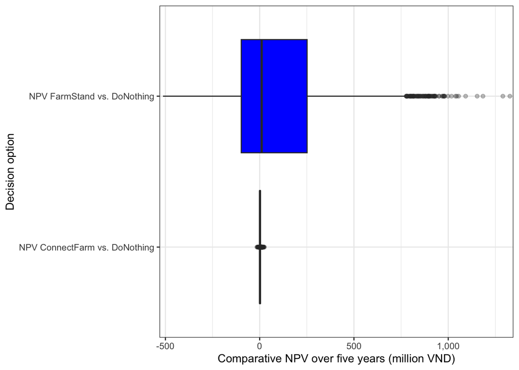

```r
# Summary statistics for both decision outcomes
summary(company_simulation_results$y[1:2])
```

```
##  decision_farmstand decision_connectFarm
##  Min.   :-512.83    Min.   :-14.881
##  1st Qu.: -97.75    1st Qu.:  0.108
##  Median :  10.49    Median :  1.658
##  Mean   :  89.43    Mean   :  2.116
##  3rd Qu.: 251.55    3rd Qu.:  3.643
##  Max.   :1326.98    Max.   : 25.239
```

```r
# 5th, 50th, and 95th percentiles
quantile(company_simulation_results$y$decision_farmstand,  probs = c(0.05, 0.50, 0.95))
```

```
##         5%        50%        95%
## -197.03294   10.49378  549.89942
```

```r
quantile(company_simulation_results$y$decision_connectFarm, probs = c(0.05, 0.50, 0.95))
```

```
##        5%       50%       95%
## -1.942046  1.658064  7.711917
```

Table of the NPV positive run-percentage across all 10,000 model runs realtive to DoNothing.

```
##                         scenario simulations positive_runs positive_percent
## decision_farmstand     FarmStand       10000          5159             51.6
## decision_connectFarm ConnectFarm       10000          7668             76.7
```

## 4.2 Annual cash flows

Annual projected cash flows for each scenario across all Monte Carlo runs. The orange crossbar marks the median. Year 1 FarmStand costs are higher due to one-time establishment expenditure.

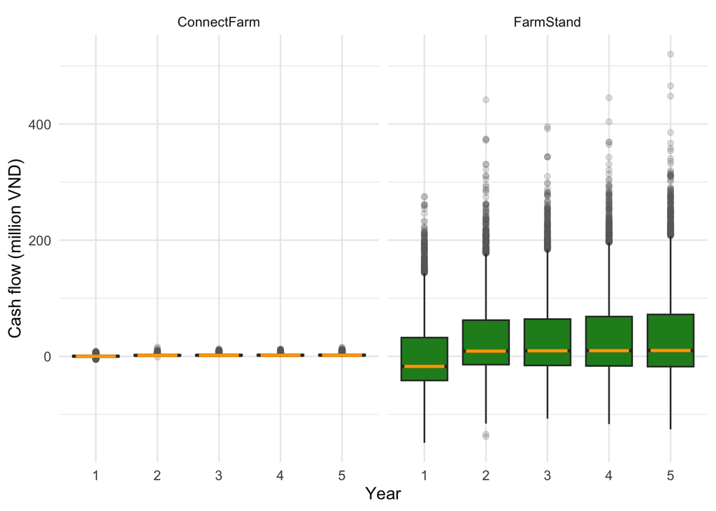

```r
cat("--- FarmStand annual cash flows ---\n")
```

```
## --- FarmStand annual cash flows ---
```

```r
summary(company_simulation_results$y[3:7])
```

```
##  cashflow_farmstand1 cashflow_farmstand2 cashflow_farmstand3
##  Min.   :-148.928    Min.   :-138.391    Min.   :-107.357
##  1st Qu.: -41.603    1st Qu.: -14.348    1st Qu.: -15.704
##  Median : -17.403    Median :   8.959    Median :   9.526
##  Mean   :  -1.119    Mean   :  27.739    Mean   :  28.411
##  3rd Qu.:  32.236    3rd Qu.:  62.255    3rd Qu.:  64.126
##  Max.   : 275.504    Max.   : 441.839    Max.   : 395.313
##  cashflow_farmstand4 cashflow_farmstand5
##  Min.   :-116.632    Min.   :-125.76
##  1st Qu.: -16.562    1st Qu.: -17.77
##  Median :   9.764    Median :  10.01
##  Mean   :  30.100    Mean   :  31.46
##  3rd Qu.:  68.409    3rd Qu.:  72.03
##  Max.   : 445.339    Max.   : 520.41
```

```r
cat("\n--- ConnectFarm annual cash flows ---\n")
```

```
##
## --- ConnectFarm annual cash flows ---
```

```r
summary(company_simulation_results$y[8:12])
```

```
##  cashflow_connectFarm1 cashflow_connectFarm2 cashflow_connectFarm3
##  Min.   :-5.81381      Min.   :-1.4648       Min.   :-1.098
##  1st Qu.:-0.78670      1st Qu.: 0.9967       1st Qu.: 1.052
##  Median : 0.08466      Median : 1.6672       Median : 1.742
##  Mean   : 0.21114      Mean   : 1.9690       Mean   : 2.067
##  3rd Qu.: 1.07256      3rd Qu.: 2.6057       3rd Qu.: 2.751
##  Max.   : 8.88192      Max.   :16.1358       Max.   :13.188
##  cashflow_connectFarm4 cashflow_connectFarm5
##  Min.   :-1.230        Min.   :-1.394
##  1st Qu.: 1.104        1st Qu.: 1.157
##  Median : 1.826        Median : 1.931
##  Mean   : 2.164        Mean   : 2.287
##  3rd Qu.: 2.870        3rd Qu.: 3.019
##  Max.   :12.404        Max.   :15.241
```

# 5 Sensitivity analysis (PLS)

We use Projection to Latent Structures (PLS) regression (fitted with the orthogonal scores algorithm via `pls::plsr`) to identify which input variables have the strongest influence on each NPV outcome and in which direction. Variables are ranked by their Variable Importance in Projection (VIP) score; only variables with VIP > 0.9 are shown. Bar colour indicates the direction of the standardised PLS coefficient: positive (blue) values increase NPV; negative (red) values decrease NPV.

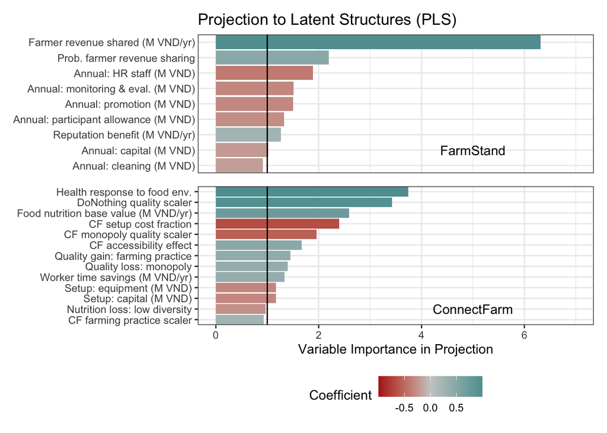

# 6 Expected Value of Perfect Information (EVPI)

The Expected Value of Perfect Information (EVPI) quantifies the maximum a decision-maker should rationally invest to eliminate uncertainty about a given input variable before making the decision. High EVPI identifies variables where targeted data collection would most change or reinforce the decision. EVPI is estimated using LOESS-smoothed empirical curves across the Monte Carlo sample, parallelised across all input variables for efficiency.

```r
source("functions/multi_EVPI.R")

evpi <- multi_EVPI(mc = mcSimulation_table,
                   first_out_var = "decision_farmstand",
                   n_cores  = parallel::detectCores() - 1,
                   mc_samples = 3000)   # subsampled for speed; EVPI stable at n = 3000
```

```
## [1] "Processing 2 output variables using 11 cores. This can take some time."
## [1] "Output variable 1 (decision_farmstand) completed."
## [1] "Output variable 2 (decision_connectFarm) completed."
```

```r
## Optional store and save step
# not necessary with the new n_cores option in multi_EVPI
# save(evpi, file = "data/data_evpi.Rda")
# load("data/data_evpi.Rda")
```

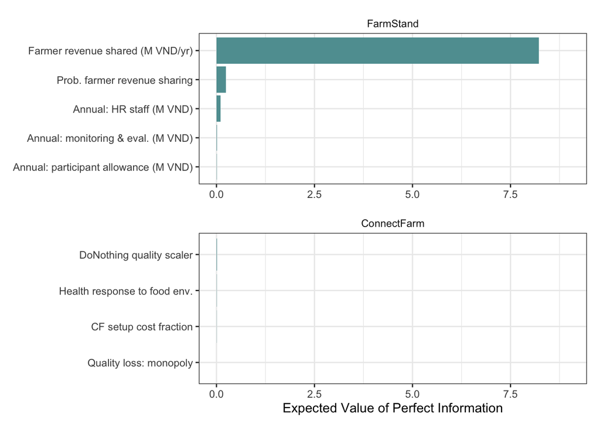

Figure: EVPI for FarmStand (top) and ConnectFarm (bottom). Only variables above the EVPI threshold are shown. Values represent the maximum investment (million VND) justified to obtain perfect information about each variable.

# 7 Food environment outcomes

The food environment score aggregates the effects of each intervention on workers’ access to safe, nutritious, and diverse vegetables, estimated as a productivity-equivalent monetary value (million VND/yr). The score is computed relative to DoNothing.

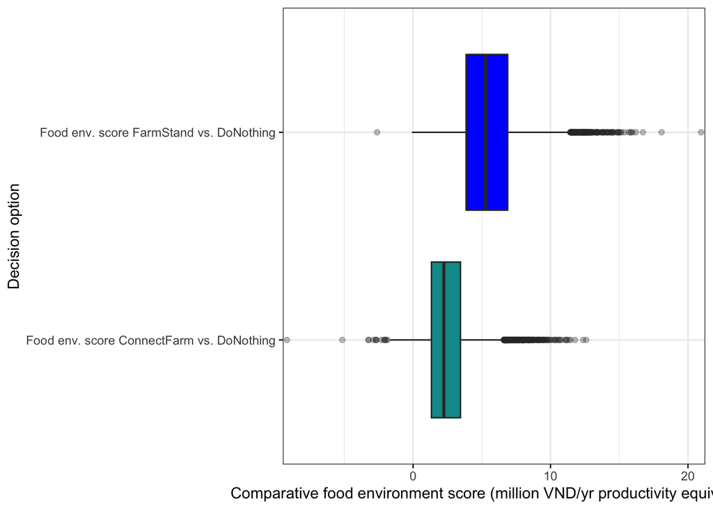

Figure: Distribution of food environment scores for FarmStand and ConnectFarm relative to DoNothing.

```r
summary(company_simulation_results$y[13:14])
```

```
##  farmstand_food_env_score connect_food_env_score
##  Min.   :-2.624           Min.   :-9.178
##  1st Qu.: 3.858           1st Qu.: 1.336
##  Median : 5.264           Median : 2.235
##  Mean   : 5.540           Mean   : 2.557
##  3rd Qu.: 6.883           3rd Qu.: 3.447
##  Max.   :20.956           Max.   :12.590
```

The modeled food-environment score difference relative to DoNothing.

```
##      scenario food_score_positive_pct positive_when_npv_positive_pct
## 1   FarmStand                   99.97                       99.98062
## 2 ConnectFarm                   98.63                       99.75222
##   positive_when_npv_nonpositive_pct
## 1                          99.95869
## 2                          94.93997
```

# 8 Code and data availability

All model code, input data, and analysis scripts are archived at:

https://github.com/sau140288/nifam_favri_companies

The model is implemented in R using the `decisionSupport` package. Monte Carlo simulation, PLS sensitivity analysis, and EVPI are all fully reproducible from the code above with `set.seed(84)`.

**Reference:** Luedeling E, Goehring L, Schiffers K, Whitney C, Fernandez E (2021). *decisionSupport: Quantitative Support of Decision Making under Uncertainty*. R package version 1.111. https://CRAN.R-project.org/package=decisionSupport

Whitney C, Luu TTG, Kopton J, Luedeling E. A decision-analysis framework for school garden investments in Vietnam: evaluating trade-offs for nutrition, biodiversity, and economic outcomes. Humanit Soc Sci Commun. 2026;13(1):580. https://doi.org/10.1057/s41599-026-07204-0

# 9 Intervention Identification and Selection

## 9.1 Food Environment Constraints

Through food environment mapping, we identified systemic constraints affecting LMI consumers in Hanoi spanning affordability, convenience, traceability, and trust. Existing coping strategies — informal sourcing, online purchasing, self-production, social networks — remain insufficient to ensure consistent access to safe vegetables.

## 9.2 Workshop Process

Four focus groups drawn from the same participant pool discussed two guiding questions:

1. Which aspects of the food environment need improvement to better support safe vegetable consumption among LMI households in inner-city Hanoi?
2. What feasible and context-appropriate interventions can address the identified challenges?

Candidate interventions were evaluated against three criteria: (1) feasibility, (2) expected effectiveness, and (3) availability of actors capable of implementation.

## 9.3 Intervention Longlist and Selection

Table S1. Candidate interventions identified during the workshop, evaluated against feasibility, actor availability, and expected effectiveness.

| No | Intervention | Selected |
| --- | --- | --- |
| 1 | Establishing social media groups (Facebook/Zalo) for discounted purchasing |  |
| 2 | Adapting PGS-based internal monitoring to reduce VietGAP certification costs |  |
| 3 | Technical measures and state incentive programs to reduce production and retail costs |  |
| 4 | Communication interventions on health benefits of safe vegetables |  |
| 5 | Priority cards enabling LMI consumers to purchase safe vegetables at reasonable prices |  |
| 6 | Training and communication on best practices across the supply chain |  |
| 7 | Supporting producer-consumer linkages through retail and marketing integration |  |
| 8 | Short supply chain via direct sale point at company campus | ✓ |
| 9 | Land consolidation policies to address fragmented production |  |
| 10 | Short supply chain via local Women’s Unions organizing residential vegetable supply |  |

## 9.4 Selected Intervention

Two short supply chain interventions received the highest votes. The Women’s Union option was excluded on the third criterion — consultations confirmed that existing organizational responsibilities limit capacity for additional roles. The on-campus direct sale model was selected for modelling and piloting.